# Standardized Precipitation Index

AnnaClaire Marley

7/30/2019

This Rmarkdown shows analysis of SPI at the watersheds bordering the Chuskas and Tsaile chaper

# Watersheds

## Chaco

### Chaco SPI

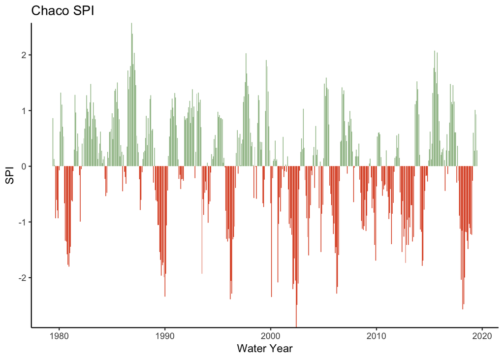

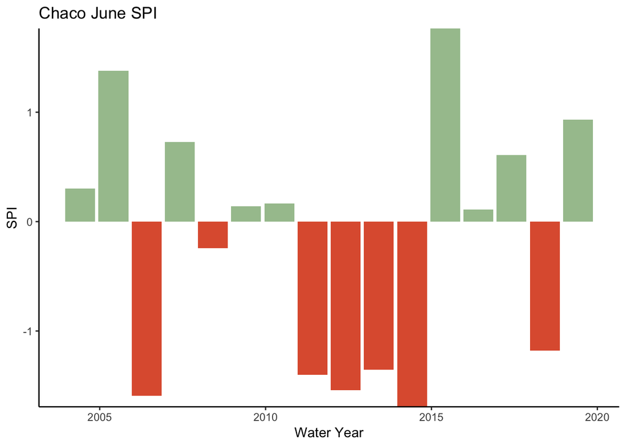

### Chaco PDSI and SPI

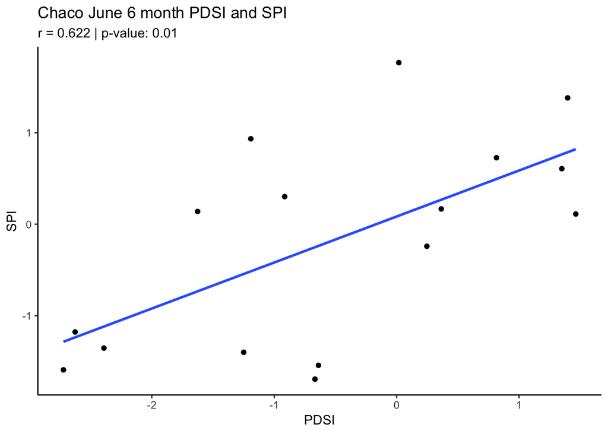

### Chaco SPI and Chuska SWE

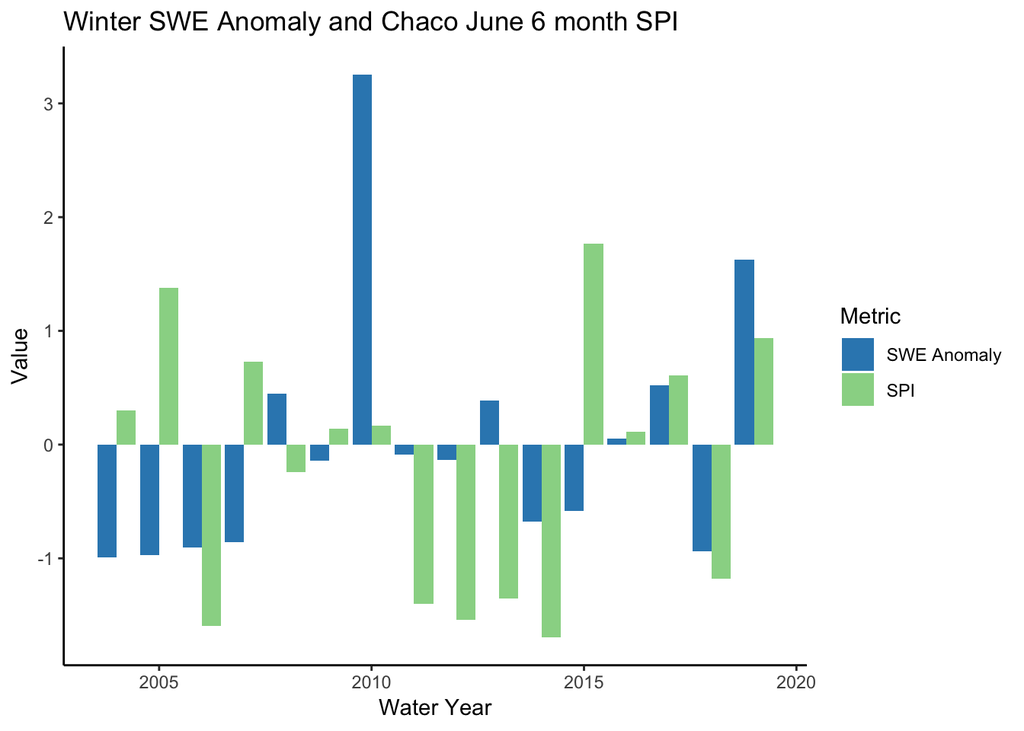

- The percent of times swe the anomaly for the year and spi had the same sign 56.25%
- The percent of times swe anomaly for the year was positive and was followed by a positive spi had the same sign out of all positive swe years 66.6666667%
- The percent of times swe anomaly for the year was negative and was followed by a negative spi had the same sign out of all negative swe years 50%

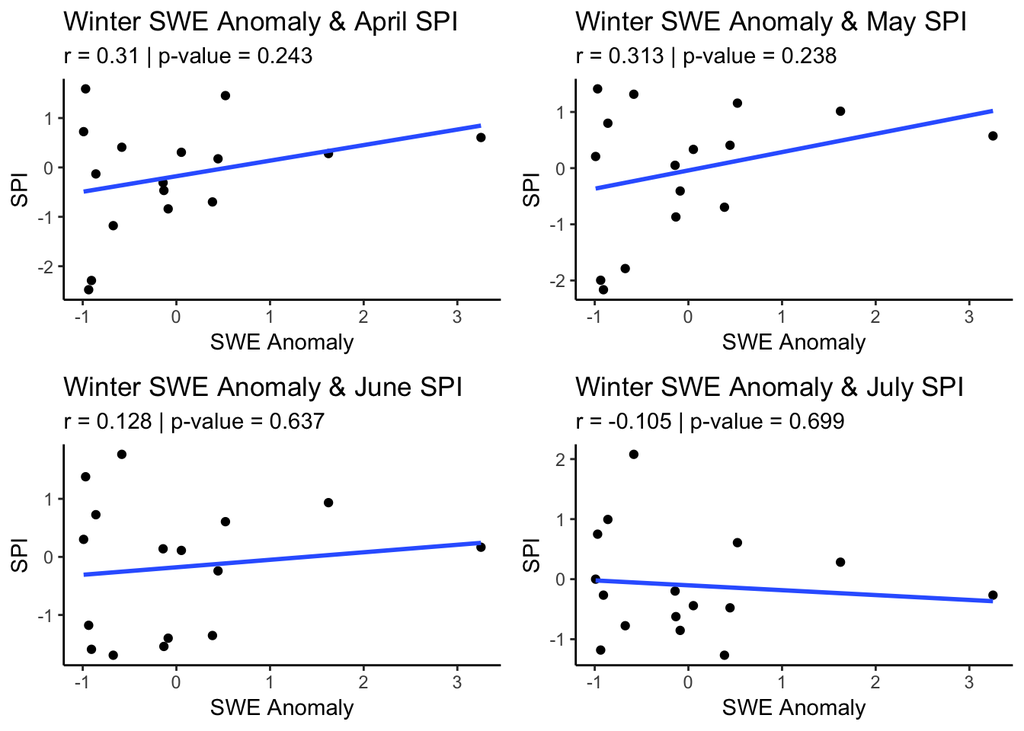

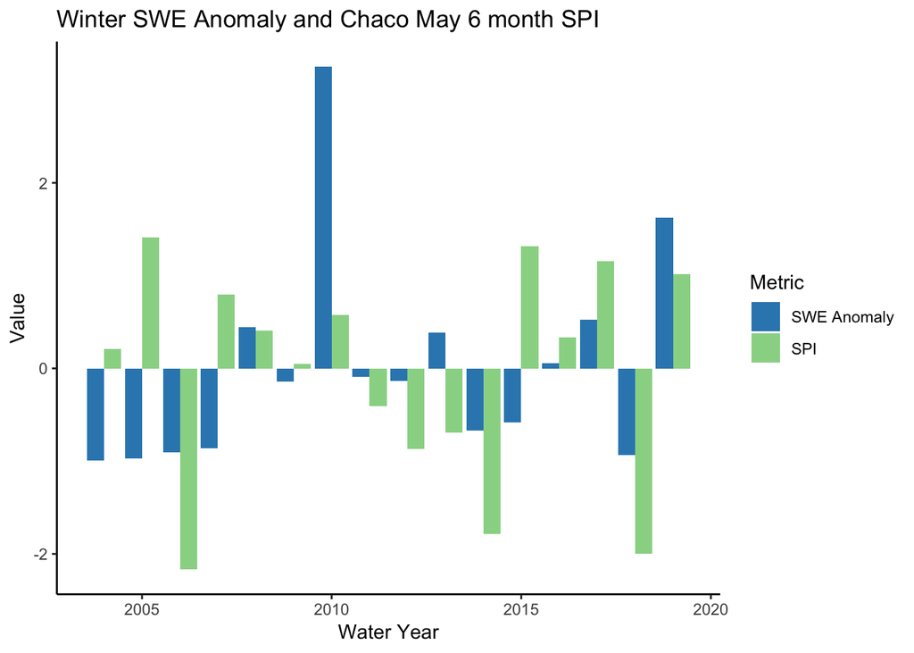

- *May* positive swe & positive spi / positive swe: 83.333%
- *May* negative swe & negative spi / negative swe: 50%
- *May* total correct: 62.5%

## Chinle

### Chinle SPI

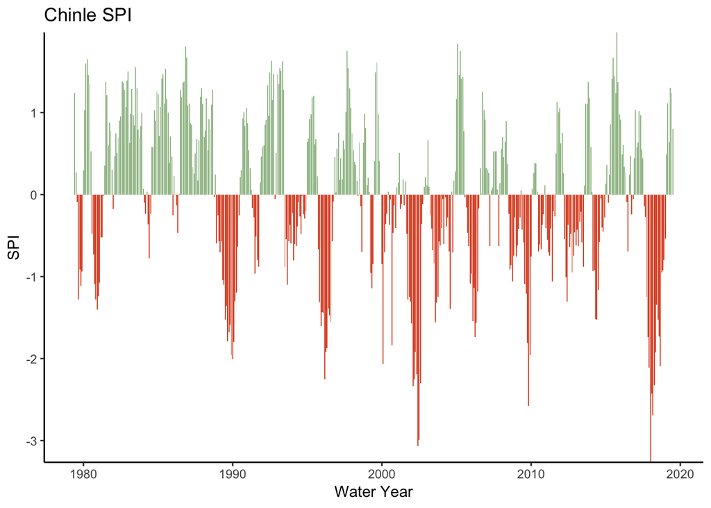

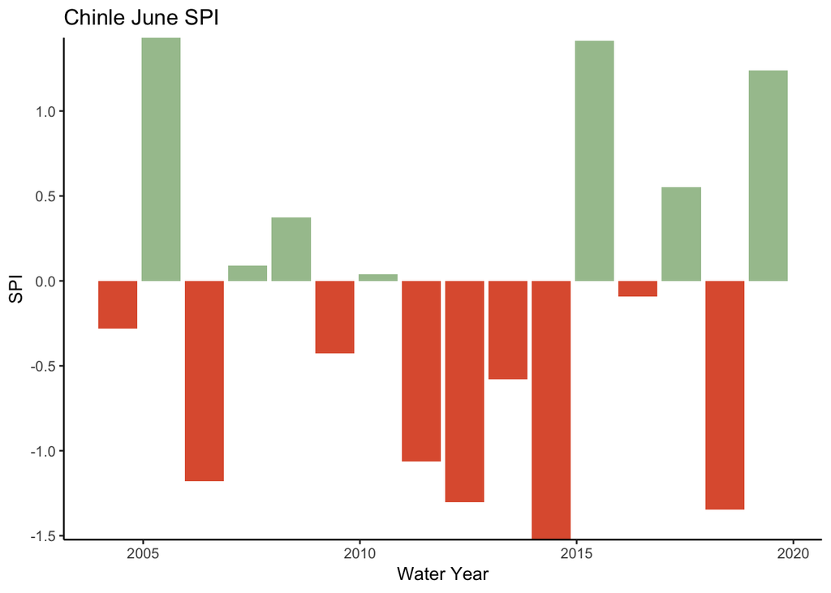

### Chinle SPI vs PDSI

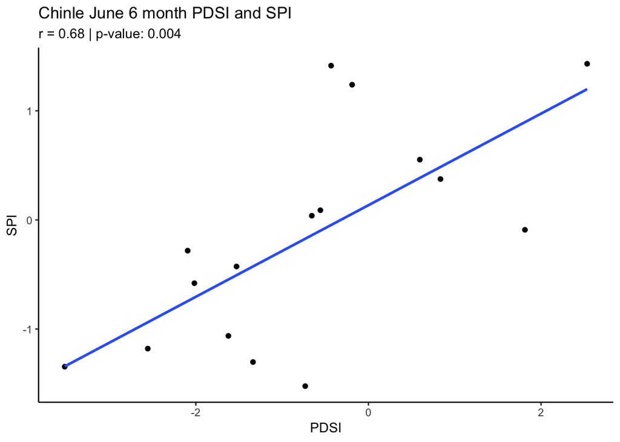

### Chinle SPI and Chuska SWE

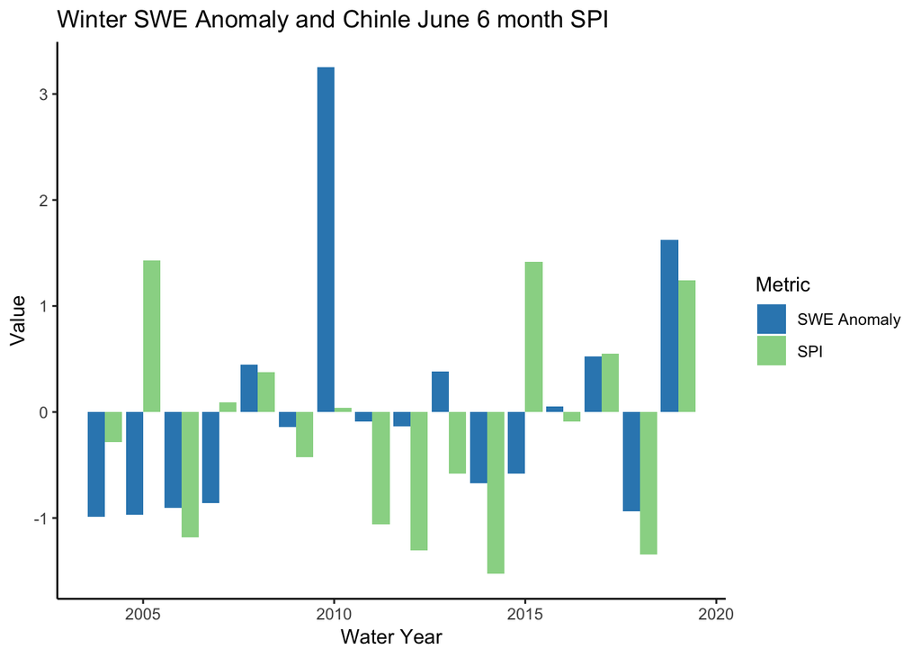

- The percent of times swe the anomaly for the year and spi had the same sign 68.75%
- The percent of times swe anomaly for the year was positive and was followed by a positive spi had the same sign out of all positive swe years 66.6666667%
- The percent of times swe anomaly for the year was negative and was followed by a negative spi had the same sign out of all negative swe years 70%

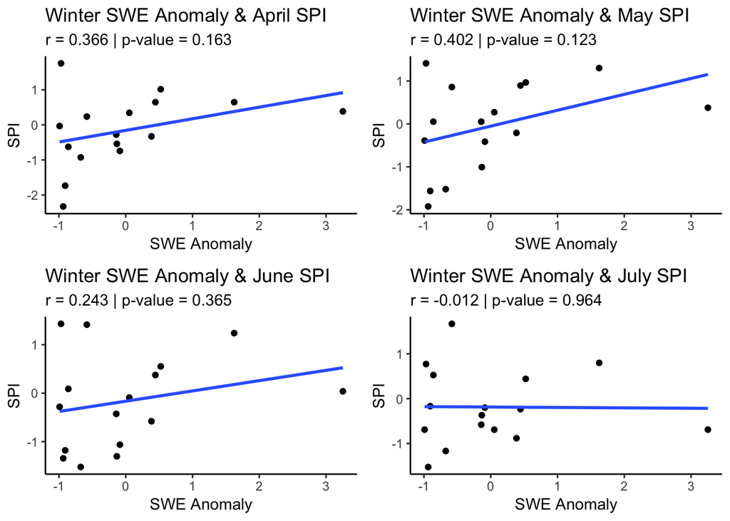

- Chuska SWE is much less corelated to Chinle July 6 month SPI than it is to June 6 month
- May had the higest correlation

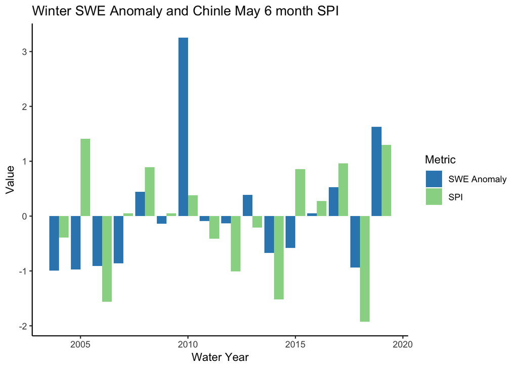

- *May* positive swe & positive spi / positive swe: 83.333%
- *May* negative swe & negative spi / negative swe: 60%
- *May* total correct: 68.75%

## Middle San Juan

[figure not shown]

[figure not shown]

### Middle San Juan SPI and PDSI

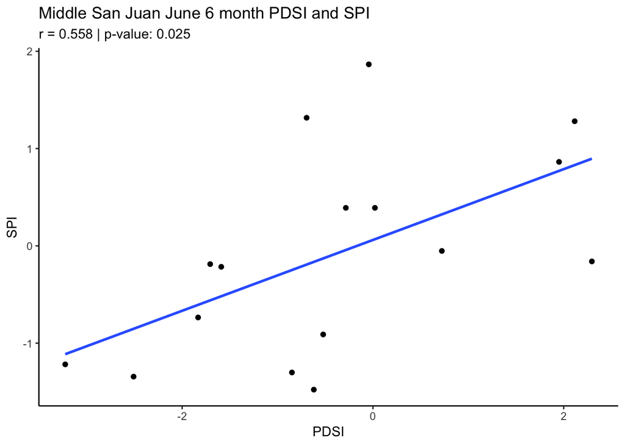

### Middle San Juan SPI and Chuska SWE

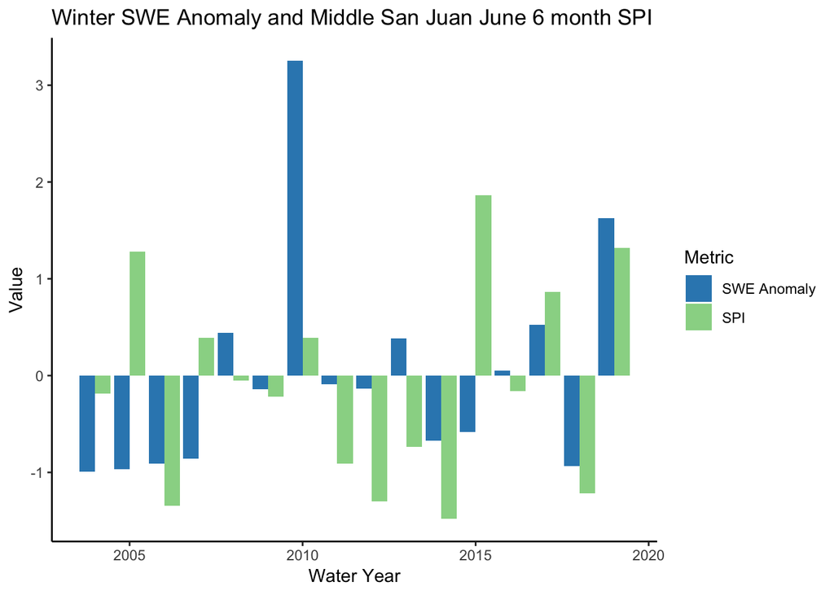

- The percent of times swe the anomaly for the year and spi had the same sign 62.5%
- The percent of times swe anomaly for the year was positive and was followed by a positive spi had the same sign out of all positive swe years 50%
- The percent of times swe anomaly for the year was negative and was followed by a negative spi had the same sign out of all negative swe years 70%

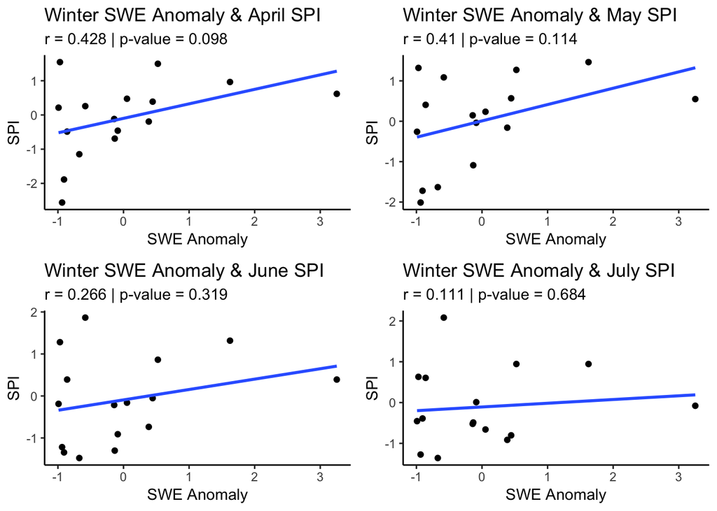

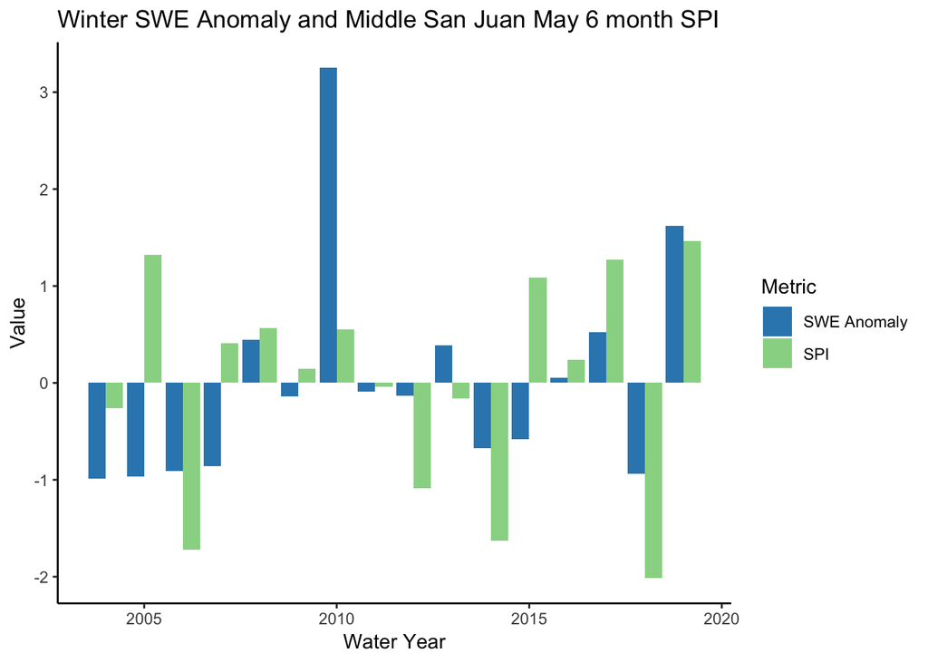

- *May* positive swe & positive spi / positive swe: 83.333%
- *May* negative swe & negative spi / negative swe: 60%
- *May* total correct: 68.75%

## Tsaile Chapter

### Tsaile SPI

#### 6 month SPI

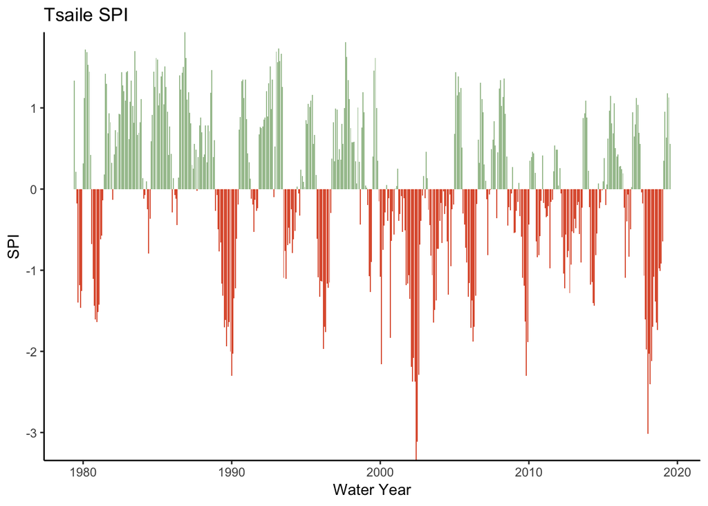

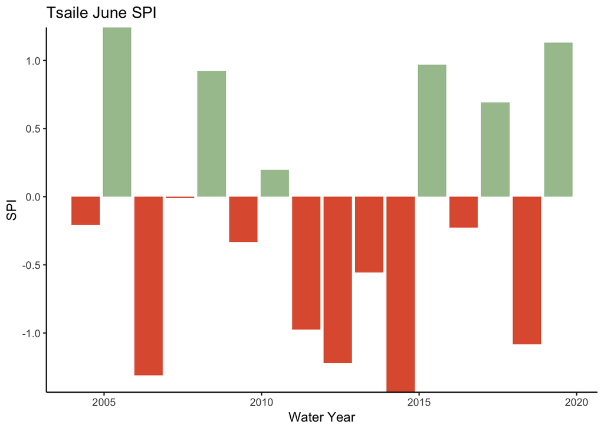

#### Tsaile SPI and Chuska SWE anomaly

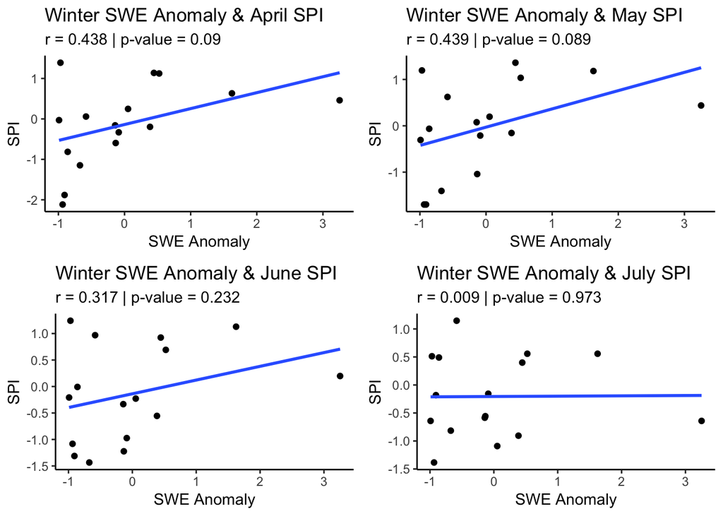

- May is has the higest correlation

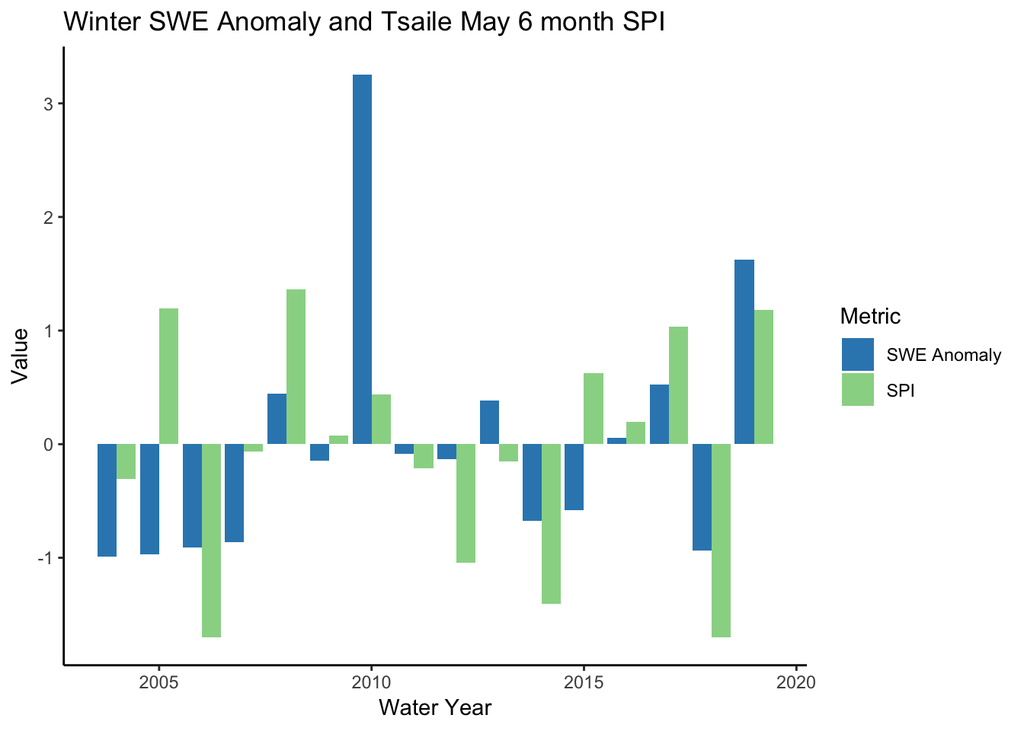

- *May* positive swe & positive spi / positive swe: 83.333%
- *May* negative swe & negative spi / negative swe: 70%
- *May* total correct: 75%

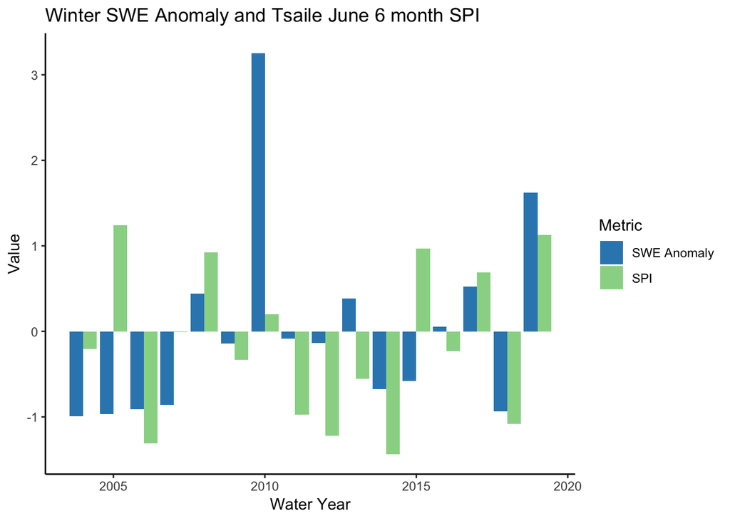

- The percent of times swe the anomaly for the year and spi had the same sign 75%
- The percent of times swe anomaly for the year was positive and was followed by a positive spi had the same sign out of all positive swe years 66.6666667%
- The percent of times swe anomaly for the year was negative and was followed by a negative spi had the same sign out of all negative swe years 80%